# Reversal_Results

Sophie Paolizzi

5/6/2022

### Markdown Purpose and Content

This markdown follows the model selection procedure for the reversal task from the base model through the random effects structure.

### Variables at Play

**ResponseCorrect_num**. Outcome variable: whether participants selected the outcome with a higher probabilistic change of accuracy.

**prevRT_log**. Reaction time in previous trial.

**rt_log**. Reaction time of current trial.

**block_number**. block number (1-5) of the task.

**trial**. Within-trial block number.

**Total-trial**. number of trials across blocks in the task.

**Task Phase**. Reversal vs. Acquisition.

**Previous Response**. The response participants selected on the previous trial.

**Previous Feedback**. Feedback recieved from the previous trial - importantly, this is prbabilistic.

**ResponseandFeedbackCategory** There are 4 possible outcomes combining previous response and previous feedback on any given trial. A participant could respond correctly and recieve congruent feedback (CRCF; correct resp, feedback = “correct”); they could response incorrectly and receieve congruent feedback (IRCF; incorrect resp, feedback = “incorrect”); they could respond correctly and recieve incongruent feedback (CRIF; correct resp, feedback = “incorrect”); or they could respond incorrectly and recieve incorrect feedback (IRIF; incorrect resp, feedback = “correct”).

### Hypotheses

As a reminder, here are the hypotheses at play:

A. In a serial reversal task, there will be a relationship between heightened BPD symptoms (as indexed by the PAI-BOR) and relatively faster detection of contingency reversals, as indicated by fewer incorrect responses post-reversal. These learners will also be less likely to choose the same option consistently across the blocks. B. In a serial reversal task, higher scores on the PSWQ will be associated with relatively slower detection of reversing reward contingencies; Participants with higher PSWQ scores will tend to be consistent in their choices and experience more errors (and less correct answers) in learning post-reversal.

### Base model

Start with the basics…. should be an effect of trial number based on tidy_markdown.

```r
minfo[["mod0"]] <- c(fixed="Intercept", l2="Intercept/Subject")
mod0 <- glmer(ResponseCorrect_num ~ 1 + (1|subject), family = binomial, control = glmerControl(optimizer = "bobyqa"),
    nAGQ = 10, data = df)

minfo[["mod1"]] <- c(fixed="Total Trial", l2="Intercept/Subject")
mod1 <- glmer(ResponseCorrect_num ~  total_trialnum + (1|subject), data = df, family = binomial, control = glmerControl(optimizer = "bobyqa"),
    nAGQ = 10)
#note: trial_number is within-block (i.e., 1-40)
minfo[["mod1.1"]] <- c(fixed="block_trial_number, block number", l2="Intercept/Subject")
mod1.1 <- glmer(ResponseCorrect_num ~  trial_number + block_number + (1|subject), data = df, family = binomial, control = glmerControl(optimizer = "bobyqa"),
    nAGQ = 10); summary(mod1.1)
```

```
## Generalized linear mixed model fit by maximum likelihood (Adaptive
##   Gauss-Hermite Quadrature, nAGQ = 10) [glmerMod]
##  Family: binomial  ( logit )
## Formula: ResponseCorrect_num ~ trial_number + block_number + (1 | subject)
##    Data: df
## Control: glmerControl(optimizer = "bobyqa")
##
##      AIC      BIC   logLik deviance df.resid
##  34630.3  34663.1 -17311.2  34622.3    27113
##
## Scaled residuals:
##     Min      1Q  Median      3Q     Max
## -2.2528 -1.1633  0.6241  0.7465  1.1378
##
## Random effects:
##  Groups  Name        Variance Std.Dev.
##  subject (Intercept) 0.1604   0.4005
## Number of obs: 27117, groups:  subject, 137
##
## Fixed effects:
##                Estimate Std. Error z value Pr(>|z|)
## (Intercept)   0.6718467  0.0512029  13.121   <2e-16 ***
## trial_number  0.0001274  0.0011199   0.114   0.9094
## block_number -0.0194119  0.0091221  -2.128   0.0333 *
## ---
## Signif. codes:  0 '***' 0.001 '**' 0.01 '*' 0.05 '.' 0.1 ' ' 1
##
## Correlation of Fixed Effects:
##             (Intr) trl_nm
## trial_numbr -0.449
## block_numbr -0.536  0.001
## optimizer (bobyqa) convergence code: 0 (OK)
## Model is nearly unidentifiable: very large eigenvalue
##  - Rescale variables?
```

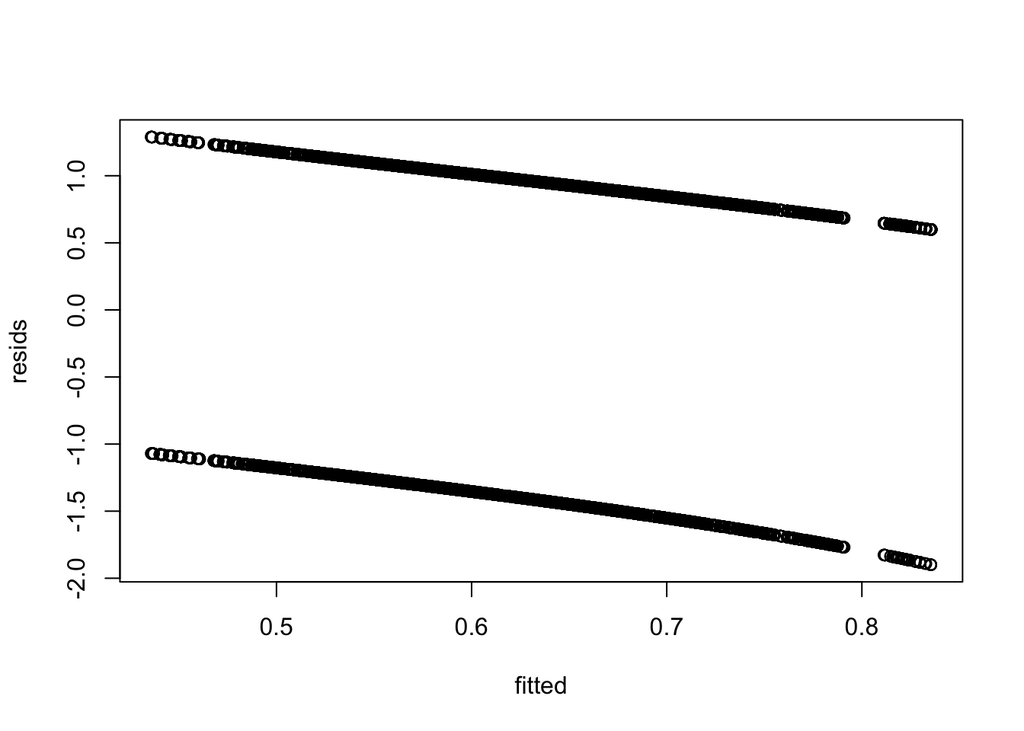

```r
resids <- residuals(mod1.1)
fitted <- fitted(mod1.1)
plot(fitted, resids)
```

```r
AIC(mod0, mod1, mod1.1)
```

```
##        df      AIC
## mod0    2 34630.85
## mod1    3 34628.59
## mod1.1  4 34630.30
```

### Rescale trials

Carry total_trial forward, it covers what we need best. Z-scoring within subject as well.

```r
minfo[["mod2"]] <- c(fixed="total_trial_z", l2="Intercept/Subject")
mod2 <- glmer(ResponseCorrect_num ~ total_trial_z + (1 |subject), data = df, family = binomial, control = glmerControl(optimizer = "bobyqa"),
    nAGQ = 10)

AIC(mod2,mod1)
```

```
##      df      AIC
## mod2  3 34628.59
## mod1  3 34628.59
```

### Add in RT

seems trial-wise RT is doing a little - no reason not to include.

```r
minfo[["mod3"]] <- c(fixed="total_trial_z, PrevRT", l2="Intercept/Subject")
mod3 <- glmer(ResponseCorrect_num ~ total_trial_z + rt_log + (1 |subject), data = df, family = binomial, control = glmerControl(optimizer = "bobyqa"))
AIC(mod2, mod3)
```

```
##      df      AIC
## mod2  3 34628.59
## mod3  4 34626.30
```

### Add in previous RT

We’ve got an effect here of previous RT; seems to be a clear winner.

```r
minfo[["mod3.1"]] <- c(fixed="total_trial_z, PrevRT, RT", l2="Intercept/Subject")
mod3.1 <- glmer(ResponseCorrect_num ~ total_trial_z + prevRT_log + rt_log + (1 |subject), data = df, family = binomial, control = glmerControl(optimizer = "bobyqa"))
AIC(mod3, mod3.1)
```

```
##        df      AIC
## mod3    4 34626.30
## mod3.1  5 34617.12
```

### Task_phase

Some clear improvement! Good news for our hypotheses re: task phase shifts

```r
minfo[["mod4"]] <- c(fixed="total_trial_z, PrevRT, RT, task phase", l2="Intercept/Subject")
mod4 <- glmer(ResponseCorrect_num ~ total_trial_z + prevRT_log + rt_log + task_phase + (1 |subject), data = df, family = binomial, control = glmerControl(optimizer = "bobyqa"))
car::Anova(mod4, type=3)
```

```
## Analysis of Deviance Table (Type III Wald chisquare tests)
##
## Response: ResponseCorrect_num
##                  Chisq Df Pr(>Chisq)
## (Intercept)     3.0673  1   0.079884 .
## total_trial_z   0.2759  1   0.599419
## prevRT_log      7.0488  1   0.007932 **
## rt_log          0.0933  1   0.759972
## task_phase    173.6382  1  < 2.2e-16 ***
## ---
## Signif. codes:  0 '***' 0.001 '**' 0.01 '*' 0.05 '.' 0.1 ' ' 1
```

```r
AIC(mod3.1, mod4)
```

```
##        df      AIC
## mod3.1  5 34617.12
## mod4    6 34444.77
```

### previous feedback (previous error, kind of)

A previous perceived error leads to choosing the wrong stimulus on the current trial. Seems like a basic win-stay lose-switch strategy, but ignoring the probabilistic part.

```r
minfo[["mod5"]] <- c(fixed="total_trial_z, PrevRT, task phase, previous feedback", l2="Intercept/Subject")
mod5 <- glmer(ResponseCorrect_num ~ total_trial_z + prevRT_log + rt_log + task_phase + prevFeedback + (1 |subject), data = df, family = binomial, control = glmerControl(optimizer = "bobyqa"))
car::Anova(mod5, type = 3)
```

```
## Analysis of Deviance Table (Type III Wald chisquare tests)
##
## Response: ResponseCorrect_num
##                  Chisq Df Pr(>Chisq)
## (Intercept)    10.1037  1    0.00148 **
## total_trial_z   0.3055  1    0.58045
## prevRT_log      6.6080  1    0.01015 *
## rt_log          0.8150  1    0.36665
## task_phase    168.3041  1    < 2e-16 ***
## prevFeedback  822.3340  1    < 2e-16 ***
## ---
## Signif. codes:  0 '***' 0.001 '**' 0.01 '*' 0.05 '.' 0.1 ' ' 1
```

```r
dependlab::render_flex_aictab(minfo=minfo, mod0, mod1, mod1.1, mod2, mod3, mod4, mod5) %>% autofit()
```

| model | fixed | l2 | logLik | AIC | 𝚫AIC | df | weight |
| --- | --- | --- | --- | --- | --- | --- | --- |
| mod0 | Intercept | Intercept/Subject | -17,313.42 | 34,630.85 | 1,017.1973 | 2 | 0 |
| mod1 | Total Trial | Intercept/Subject | -17,311.30 | 34,628.59 | 1,014.9471 | 3 | 0 |
| mod1.1 | block_trial_number, block number | Intercept/Subject | -17,311.15 | 34,630.30 | 1,016.6547 | 4 | 0 |
| mod2 | total_trial_z | Intercept/Subject | -17,311.29 | 34,628.59 | 1,014.9421 | 3 | 0 |
| mod3 | total_trial_z, PrevRT | Intercept/Subject | -17,309.15 | 34,626.30 | 1,012.6557 | 4 | 0 |
| mod3.1 | total_trial_z, PrevRT, RT | Intercept/Subject |  |  |  |  |  |
| mod4 | total_trial_z, PrevRT, RT, task phase | Intercept/Subject | -17,216.39 | 34,444.77 | 831.1228 | 6 | 0 |
| mod5 | total_trial_z, PrevRT, task phase, previous feedback | Intercept/Subject | -16,799.82 | 33,613.65 | 0.0000 | 7 | 1 |

### previous response

I’m thinking of this as a more direct “stickiness” measure. The clear winner here is the model with an interaction between feedback and response (6.1). We starting to see some upward trends in collinearity we should watch out for.

```r
minfo <- list()
minfo[["mod6"]] <- c(fixed="tot_trial_z, PrevRT, RT, phase, prevFeed, prevResp", l2="Intercept/Subject")
mod6 <- glmer(ResponseCorrect_num ~ total_trial_z + prevRT_log + rt_log + task_phase + prevFeedback + prevResponse + (1 |subject), data = df, family = binomial, control = glmerControl(optimizer = "bobyqa"))

minfo[["mod6.1"]] <- c(fixed="tot_trial_z, PrevRT, RT, phase, prevFeed*prevResp", l2="Intercept/Subject")
mod6.1 <- glmer(ResponseCorrect_num ~ total_trial_z + prevRT_log + rt_log + task_phase + prevFeedback*prevResponse + (1 |subject), data = df, family = binomial, control = glmerControl(optimizer = "bobyqa"))
AIC(mod5, mod6, mod6.1)
```

```
##        df      AIC
## mod5    7 33613.65
## mod6    8 31816.27
## mod6.1  9 29836.31
```

```r
car::vif(mod6.1)
```

```
##             total_trial_z                prevRT_log                    rt_log
##                  1.062485                  1.192555                  1.196150
##                task_phase              prevFeedback              prevResponse
##                  1.034023                  1.731268                  3.329108
## prevFeedback:prevResponse
##                  4.578516
```

```r
car::Anova(mod6.1, type = 3)
```

```
## Analysis of Deviance Table (Type III Wald chisquare tests)
##
## Response: ResponseCorrect_num
##                               Chisq Df Pr(>Chisq)
## (Intercept)                 39.9141  1  2.654e-10 ***
## total_trial_z                0.6584  1   0.417110
## prevRT_log                  10.3736  1   0.001278 **
## rt_log                       0.1187  1   0.730411
## task_phase                 113.4124  1  < 2.2e-16 ***
## prevFeedback              1287.3397  1  < 2.2e-16 ***
## prevResponse              3014.9058  1  < 2.2e-16 ***
## prevFeedback:prevResponse 1790.0053  1  < 2.2e-16 ***
## ---
## Signif. codes:  0 '***' 0.001 '**' 0.01 '*' 0.05 '.' 0.1 ' ' 1
```

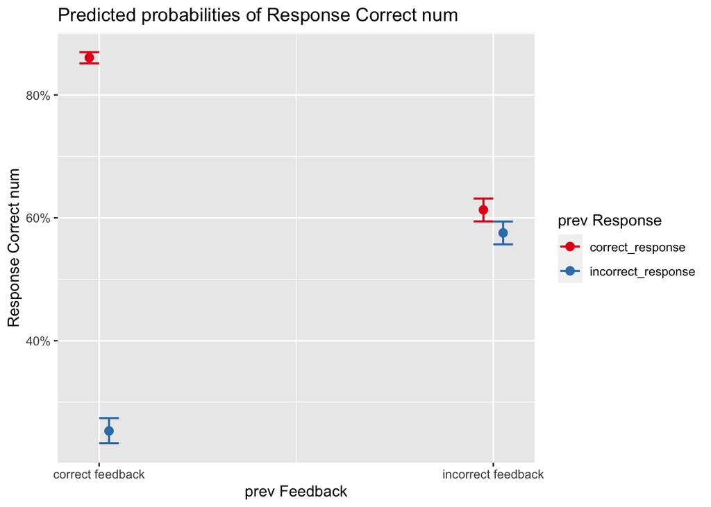

```r
plot_model(mod6.1, type = "pred", terms = c("prevFeedback", "prevResponse"))
```

### Interaction with phase and feedback

We see some potential here for a phasexfeedback interaction, suggesting that previous feedback in the reversal block is slightly less salient.

```r
minfo[["mod6.2"]] <- c(fixed="tot_trial_z, PrevRT, RT, phase*prevFeed, prevResp*prevFeed", l2="Intercept/Subject")
mod6.2 <- glmer(ResponseCorrect_num ~ total_trial_z + prevRT_log + rt_log  + task_phase + task_phase*prevFeedback + prevFeedback*prevResponse + (1 |subject), data = df, family = binomial, control = glmerControl(optimizer = "bobyqa"))
AIC(mod6.1, mod6.2)
```

```
##        df      AIC
## mod6.1  9 29836.31
## mod6.2 10 29835.05
```

```r
dependlab::render_flex_aictab(minfo=minfo, mod0, mod1, mod1.1, mod2, mod3, mod4, mod5, mod6, mod6.1, mod6.2) %>% autofit()
```

| model | fixed | l2 | logLik | AIC | 𝚫AIC | df | weight |
| --- | --- | --- | --- | --- | --- | --- | --- |
| mod6 | tot_trial_z, PrevRT, RT, phase, prevFeed, prevResp | Intercept/Subject | -15,900.14 | 31,816.27 | 1,981.222103 | 8 | 0.000 |
| mod6.1 | tot_trial_z, PrevRT, RT, phase, prevFeed*prevResp | Intercept/Subject | -14,909.15 | 29,836.31 | 1.255086 | 9 | 0.348 |
| mod6.2 | tot_trial_z, PrevRT, RT, phase*prevFeed, prevResp*prevFeed | Intercept/Subject | -14,907.53 | 29,835.05 | 0.000000 | 10 | 0.652 |

```r
car::Anova(mod6.2, type = 3)
```

```
## Analysis of Deviance Table (Type III Wald chisquare tests)
##
## Response: ResponseCorrect_num
##                               Chisq Df Pr(>Chisq)
## (Intercept)                 41.6607  1  1.086e-10 ***
## total_trial_z                0.6838  1   0.408270
## prevRT_log                  10.2923  1   0.001336 **
## rt_log                       0.1321  1   0.716260
## task_phase                  68.4759  1  < 2.2e-16 ***
## prevFeedback               862.9077  1  < 2.2e-16 ***
## prevResponse              3010.1350  1  < 2.2e-16 ***
## task_phase:prevFeedback      3.2551  1   0.071202 .
## prevFeedback:prevResponse 1783.5384  1  < 2.2e-16 ***
## ---
## Signif. codes:  0 '***' 0.001 '**' 0.01 '*' 0.05 '.' 0.1 ' ' 1
```

### 3-way interaction with phase, feedback, and response

Also seems clear we shouldn’t hope for a 3-way interaction with task phase, previous feedback, and previous response, collinearity is intense.

```r
minfo[["mod6.3"]] <- c(fixed="tot_trial_z, PrevRT, RT, phase, phase*prevFeed, prevFeed*prevResp", l2="Intercept/Subject")
mod6.3 <- glmer(ResponseCorrect_num ~ total_trial_z + rt_log + prevRT_log + task_phase + task_phase*prevFeedback*prevResponse + (1 |subject), data = df, family = binomial, control = glmerControl(optimizer = "bobyqa")) #very collinear, probably not salvageable
car::vif(mod6.3)
```

```
##                        total_trial_z                               rt_log
##                             1.062283                             1.197634
##                           prevRT_log                           task_phase
##                             1.193474                             3.203906
##                         prevFeedback                         prevResponse
##                             3.520841                             7.668536
##              task_phase:prevFeedback              task_phase:prevResponse
##                             6.024066                            10.152123
##            prevFeedback:prevResponse task_phase:prevFeedback:prevResponse
##                            10.052773                            12.606828
```

```r
car::Anova(mod6.3, type = 3)
```

```
## Analysis of Deviance Table (Type III Wald chisquare tests)
##
## Response: ResponseCorrect_num
##                                          Chisq Df Pr(>Chisq)
## (Intercept)                            45.5153  1  1.514e-11 ***
## total_trial_z                           0.6731  1   0.411987
## rt_log                                  0.1779  1   0.673168
## prevRT_log                              9.9907  1   0.001573 **
## task_phase                             91.1020  1  < 2.2e-16 ***
## prevFeedback                          835.9090  1  < 2.2e-16 ***
## prevResponse                         1573.8306  1  < 2.2e-16 ***
## task_phase:prevFeedback                28.6750  1  8.560e-08 ***
## task_phase:prevResponse                23.5596  1  1.211e-06 ***
## prevFeedback:prevResponse            1096.1285  1  < 2.2e-16 ***
## task_phase:prevFeedback:prevResponse   41.8010  1  1.011e-10 ***
## ---
## Signif. codes:  0 '***' 0.001 '**' 0.01 '*' 0.05 '.' 0.1 ' ' 1
```

### Decomposing 3-way interaction

Pretty close in fit to our previous model, but the interactions are not significant. Maybe makes sense to carry forward 6.2 for now?

```r
minfo[["mod6.4"]] <- c(fixed="tot_trial_z, PrevRT, RT, phase, , prevResp*phase, phase*prevFeed, prevFeed*prevResp", l2="Intercept/Subject")
mod6.4 <- glmer(ResponseCorrect_num ~ total_trial_z + prevRT_log + rt_log + task_phase*prevResponse + prevFeedback*task_phase + prevFeedback*prevResponse + (1 |subject), data = df, family = binomial, control = glmerControl(optimizer = "bobyqa"))
car::Anova(mod6.4, type = 3)
```

```
## Analysis of Deviance Table (Type III Wald chisquare tests)
##
## Response: ResponseCorrect_num
##                               Chisq Df Pr(>Chisq)
## (Intercept)                 41.2519  1  1.338e-10 ***
## total_trial_z                0.6723  1   0.412255
## prevRT_log                  10.2132  1   0.001394 **
## rt_log                       0.1429  1   0.705430
## task_phase                  59.0126  1  1.567e-14 ***
## prevResponse              2175.9474  1  < 2.2e-16 ***
## prevFeedback               844.2954  1  < 2.2e-16 ***
## task_phase:prevResponse      0.5017  1   0.478763
## task_phase:prevFeedback      3.7542  1   0.052674 .
## prevResponse:prevFeedback 1781.6720  1  < 2.2e-16 ***
## ---
## Signif. codes:  0 '***' 0.001 '**' 0.01 '*' 0.05 '.' 0.1 ' ' 1
```

```r
dependlab::render_flex_aictab(minfo=minfo, mod6, mod6.1, mod6.2,mod6.3, mod6.4) %>% autofit()
```

| model | fixed | l2 | logLik | AIC | 𝚫AIC | df | weight |
| --- | --- | --- | --- | --- | --- | --- | --- |
| mod6 | tot_trial_z, PrevRT, RT, phase, prevFeed, prevResp | Intercept/Subject | -15,900.14 | 31,816.27 | 2,019.74492 | 8 | 0 |
| mod6.1 | tot_trial_z, PrevRT, RT, phase, prevFeed*prevResp | Intercept/Subject | -14,909.15 | 29,836.31 | 39.77790 | 9 | 0 |
| mod6.2 | tot_trial_z, PrevRT, RT, phase*prevFeed, prevResp*prevFeed | Intercept/Subject | -14,907.53 | 29,835.05 | 38.52281 | 10 | 0 |
| mod6.3 | tot_trial_z, PrevRT, RT, phase, phase*prevFeed, prevFeed*prevResp | Intercept/Subject | -14,886.26 | 29,796.53 | 0.00000 | 12 | 1 |
| mod6.4 | tot_trial_z, PrevRT, RT, phase, , prevResp*phase, phase*prevFeed, prevFeed*prevResp | Intercept/Subject | -14,907.28 | 29,836.55 | 40.02121 | 11 | 0 |

### Attempt to understand 4-way categories: responseAndFeedbackCategory variable….

Before we officially move on, we do have an alternative variable that has 4 levels that sort of embodies the previousresponsexprevious feedback interaction, but it’s not working the way I’d like; I don’t know of a dummy code that lets me do a 4-way contrast… we should stick with 6.2 for now. We can definitely say the prevresponse*prevfeeback interaction is in: the others seem like they might have potential once we start playing with random effects.

```r
# mod7 <- glmer(ResponseCorrect_num ~ total_trial_z + prevRT_log + rt_log + responseAndFeedbackCategory*task_phase + (1 |subject), data = df, family = binomial, control = glmerControl(optimizer = "bobyqa")) #she's a degenerate Hessian, not worth considering.
```

### Key Random Effects

**Subject**. We are interested in within-subject variation, for sure.

**Previous Response**. Clear “stickiness” effect of previous response - we want to know if this is heterogenous by subject.

**Previous Feedback**. Clear impact of feedback on current choice - we want to know if this is heterogenous by subject.

**Task Phase**. It is critical that we understand how the task phase manipulation plays into this.

#### Basic Random Slopes

Seems there are worthwhile random slopes of task phase, previous response, and previous feedback.

```r
minfo[["mod8a"]] <- c(fixed="tot_trial_z, PrevRT, phase*prevFeed, prevFeed*prevResp", l2="Intercept + prevResp/Subject")
mod8a <- glmer(ResponseCorrect_num ~ total_trial_z + prevRT_log + rt_log + prevFeedback*task_phase + prevFeedback*prevResponse + (1 + prevResponse |subject), data = data, family = binomial, control = glmerControl(optimizer = "bobyqa"))

minfo[["mod8b"]] <- c(fixed="tot_trial_z, PrevRT, phase*prevFeed, prevFeed*prevResp", l2="Intercept + prevResp+prevFeed/Subject")
mod8b <- glmer(ResponseCorrect_num ~ total_trial_z + prevRT_log + rt_log + prevFeedback*task_phase + prevFeedback*prevResponse + (1 + prevResponse + prevFeedback |subject), data = data, family = binomial, control = glmerControl(optimizer = "bobyqa"))

minfo[["mod8c"]] <- c(fixed="tot_trial_z, PrevRT, phase*prevFeed, prevFeed*prevResp", l2="Intercept + prevResp+prevFeed+task_phase/Subject")
mod8c <- glmer(ResponseCorrect_num ~ total_trial_z + prevRT_log + rt_log + prevFeedback*task_phase + prevFeedback*prevResponse + (1 + prevResponse + prevFeedback + task_phase |subject), data = data, family = binomial, control = glmerControl(optimizer = "bobyqa"))
car::Anova(mod8c, type = 3)
```

```
## Analysis of Deviance Table (Type III Wald chisquare tests)
##
## Response: ResponseCorrect_num
##                               Chisq Df Pr(>Chisq)
## (Intercept)                 48.3213  1  3.618e-12 ***
## total_trial_z                0.1205  1   0.728494
## prevRT_log                   9.0128  1   0.002681 **
## rt_log                       0.1734  1   0.677068
## prevFeedback               854.2581  1  < 2.2e-16 ***
## task_phase                  48.2475  1  3.757e-12 ***
## prevResponse               743.3597  1  < 2.2e-16 ***
## prevFeedback:task_phase      5.9266  1   0.014914 *
## prevFeedback:prevResponse 1873.6892  1  < 2.2e-16 ***
## ---
## Signif. codes:  0 '***' 0.001 '**' 0.01 '*' 0.05 '.' 0.1 ' ' 1
```

```r
dependlab::render_flex_aictab(minfo=minfo, mod6, mod6.1, mod6.2, mod6.4, mod8a, mod8b, mod8c) %>% autofit()
```

| model | fixed | l2 | logLik | AIC | 𝚫AIC | df | weight |
| --- | --- | --- | --- | --- | --- | --- | --- |
| mod6 | tot_trial_z, PrevRT, RT, phase, prevFeed, prevResp | Intercept/Subject | -15,900.14 | 31,816.27 | 3,474.68481 | 8 | 0 |
| mod6.1 | tot_trial_z, PrevRT, RT, phase, prevFeed*prevResp | Intercept/Subject | -14,909.15 | 29,836.31 | 1,494.71779 | 9 | 0 |
| mod6.2 | tot_trial_z, PrevRT, RT, phase*prevFeed, prevResp*prevFeed | Intercept/Subject | -14,907.53 | 29,835.05 | 1,493.46270 | 10 | 0 |
| mod6.3 | tot_trial_z, PrevRT, RT, phase, phase*prevFeed, prevFeed*prevResp | Intercept/Subject |  |  |  |  |  |
| mod6.4 | tot_trial_z, PrevRT, RT, phase, , prevResp*phase, phase*prevFeed, prevFeed*prevResp | Intercept/Subject | -14,907.28 | 29,836.55 | 1,494.96111 | 11 | 0 |
| mod8a | tot_trial_z, PrevRT, phase*prevFeed, prevFeed*prevResp | Intercept + prevResp/Subject | -14,177.30 | 28,378.60 | 37.00613 | 12 | 0 |
| mod8b | tot_trial_z, PrevRT, phase*prevFeed, prevFeed*prevResp | Intercept + prevResp+prevFeed/Subject | -14,174.95 | 28,379.91 | 38.31828 | 15 | 0 |
| mod8c | tot_trial_z, PrevRT, phase*prevFeed, prevFeed*prevResp | Intercept + prevResp+prevFeed+task_phase/Subject | -14,151.79 | 28,341.59 | 0.00000 | 19 | 1 |

```r
car::vif(mod8c)
```

```
##             total_trial_z                prevRT_log                    rt_log
##                  1.052482                  1.210634                  1.212222
##              prevFeedback                task_phase              prevResponse
##                  2.341863                  1.980970                  1.352574
##   prevFeedback:task_phase prevFeedback:prevResponse
##                  2.838311                  1.783542
```

### Examine random effects structure

Very clear correlations between random effects. Seems as though feedback and task phase are negatively correlated,

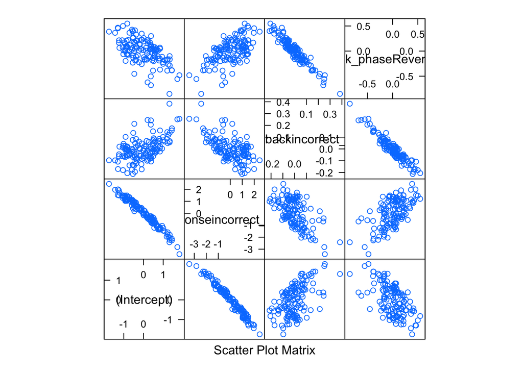

```r
plot(ranef(mod8c))
```

```r
VarCorr(mod8c)
```

```
##  Groups  Name                           Std.Dev. Corr
##  subject (Intercept)                    0.80618
##          prevResponseincorrect_response 1.20614  -0.966
##          prevFeedbackincorrect_feedback 0.15108   0.348 -0.439
##          task_phaseReversal             0.32612  -0.485  0.470 -0.765
```

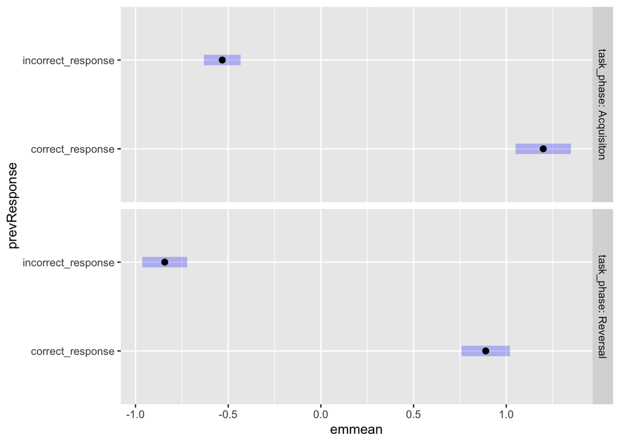

```r
PrevResp_taskphase <- emmeans(mod8c, ~  prevResponse | task_phase, sigmaAdjust = c(TRUE, FALSE))
plot(PrevResp_taskphase)
```

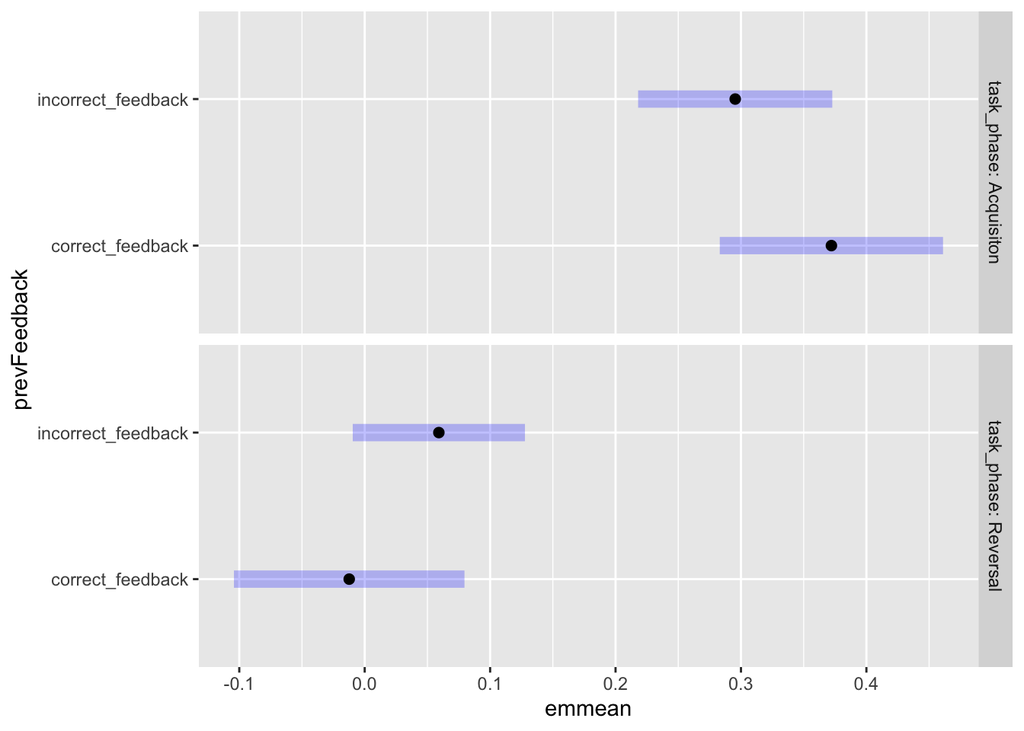

```r
PrevFeedback_taskphase <- emmeans(mod8c, ~  prevFeedback | task_phase, sigmaAdjust = c(TRUE, FALSE))
plot(PrevFeedback_taskphase)
```

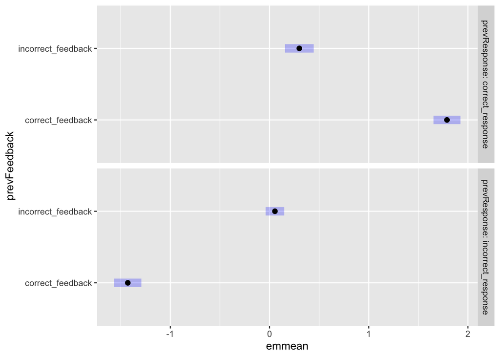

```r
prevResponse_Feedback <- emmeans(mod8c, ~   prevFeedback | prevResponse, sigmaAdjust = c(TRUE, FALSE))
plot(prevResponse_Feedback) #if you get correct
```

#### Nested slope in task phase Degenerate hessian if both random slope and nested effect are present. Seem the straight random effects are the winners here.

```r
# mod8 <- glmer(ResponseCorrect_num ~ total_trial_z + prevRT_log + rt_log + prevFeedback*task_phase + prevFeedback*prevResponse + (1 + prevResponse + prevFeedback + task_phase |subject) + (1 | subject:task_phase), data = data, family = binomial, control = glmerControl(optimizer = "bobyqa"))

minfo[["mod8.1"]] <- c(fixed="tot_trial_z, PrevRT, phase*prevFeed, prevFeed*prevResp", l2="Intercept + Intercept+prevResp+prevFeed+task_phase/Subject, Intercept/Subject:task_phase")
mod8.1 <- glmer(ResponseCorrect_num ~ total_trial_z + prevRT_log + rt_log + prevFeedback*task_phase + prevFeedback*prevResponse + (1 + prevResponse + prevFeedback |subject) + (1 | subject:task_phase), data = data, family = binomial, control = glmerControl(optimizer = "bobyqa"))

VarCorr(mod8.1)
```

```
##  Groups             Name                           Std.Dev. Corr
##  subject:task_phase (Intercept)                    0.22891
##  subject            (Intercept)                    0.72078
##                     prevResponseincorrect_response 1.21069  -0.970
##                     prevFeedbackincorrect_feedback 0.15125   0.234 -0.459
```

```r
dependlab::render_flex_aictab(minfo=minfo, mod6, mod6.1, mod6.2, mod6.4, mod8a, mod8b, mod8c, mod8.1) %>% autofit()
```

| model | fixed | l2 | logLik | AIC | 𝚫AIC | df | weight |
| --- | --- | --- | --- | --- | --- | --- | --- |
| mod6 | tot_trial_z, PrevRT, RT, phase, prevFeed, prevResp | Intercept/Subject | -15,900.14 | 31,816.27 | 3,474.684808 | 8 | 0.000 |
| mod6.1 | tot_trial_z, PrevRT, RT, phase, prevFeed*prevResp | Intercept/Subject | -14,909.15 | 29,836.31 | 1,494.717790 | 9 | 0.000 |
| mod6.2 | tot_trial_z, PrevRT, RT, phase*prevFeed, prevResp*prevFeed | Intercept/Subject | -14,907.53 | 29,835.05 | 1,493.462704 | 10 | 0.000 |
| mod6.3 | tot_trial_z, PrevRT, RT, phase, phase*prevFeed, prevFeed*prevResp | Intercept/Subject |  |  |  |  |  |
| mod6.4 | tot_trial_z, PrevRT, RT, phase, , prevResp*phase, phase*prevFeed, prevFeed*prevResp | Intercept/Subject | -14,907.28 | 29,836.55 | 1,494.961105 | 11 | 0.000 |
| mod8a | tot_trial_z, PrevRT, phase*prevFeed, prevFeed*prevResp | Intercept + prevResp/Subject | -14,177.30 | 28,378.60 | 37.006126 | 12 | 0.000 |
| mod8b | tot_trial_z, PrevRT, phase*prevFeed, prevFeed*prevResp | Intercept + prevResp+prevFeed/Subject | -14,174.95 | 28,379.91 | 38.318279 | 15 | 0.000 |
| mod8c | tot_trial_z, PrevRT, phase*prevFeed, prevFeed*prevResp | Intercept + prevResp+prevFeed+task_phase/Subject | -14,151.79 | 28,341.59 | 0.000000 | 19 | 0.985 |
| mod8.1 | tot_trial_z, PrevRT, phase*prevFeed, prevFeed*prevResp | Intercept + Intercept+prevResp+prevFeed+task_phase/Subject, Intercept/Subject:task_phase | -14,158.96 | 28,349.92 | 8.327248 | 16 | 0.015 |

Remaining Questions:

1.) Is the amount of correlation in the random effects structure a problem? 2.) Is there something we can do to reduce collinearity and get the 3-way interaction model tractable?